# gmm_vs_others

```python
from icecream import ic
import math
from scipy.stats import norm
import numpy as np
from sklearn.mixture import GaussianMixture
import matplotlib.pyplot as plt
from scipy.stats import genextreme as gev
import scipy.stats as stats
from matplotlib.patches import Rectangle
import pandas as pd
```

### Testing the goodness-of-fit of GMM vs other distributions

I tested the goodness-of-fit of different distributions with data from a grid cell of MPI-ESM-1-2-HR for historical period. However, this is a not specific choice. I just wanted to see how the GMM performs on a real bimodal distribution. I previouslt tested the distribution with dummy data.

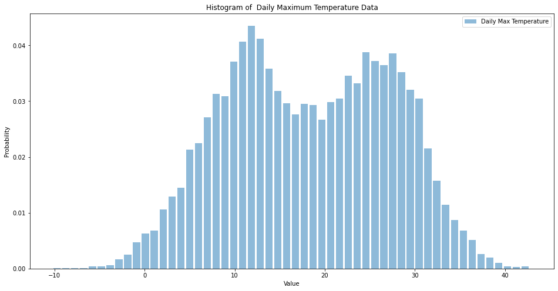

```python
# means = [15, 25]
# stds = [3, 5]
# weights = [0.5, 0.5]
# ic(means, stds, weights)
# component_1 = np.random.normal(means[0], stds[0], int(weights[0]*n))
# component_2 = np.random.normal(components_dict[1]['mean'], components_dict[1]['stdev'], int(weights[1]*n))
# data = np.concatenate((component_1, component_2))

# I choose historical data for Istanbul as it is in MED region, and from the analysis in the paper we know that all grid cells in MED region follow bimodal distribution.

data_istanbul = pd.read_csv('istanbul.csv', sep='\s+')
data = data_istanbul['lat'].values
bin_size = math.ceil(max(data))-math.floor(min(data))
n = len(data)

x = np.linspace(min(data), max(data), n)

# remove nan values from data
data = data[~np.isnan(data)]
column_names = data_istanbul.columns.to_list()[1:] + ['nan']
data_istanbul.columns = column_names
data_istanbul.drop('nan', axis=1, inplace=True)
data_istanbul['date'] = pd.to_datetime(data_istanbul['date'])

plt.figure(figsize=(16, 8))
plt.hist(data_istanbul['value'], bins=bin_size, histtype='bar', width=0.8, density=True, alpha=0.5)
plt.title('Histogram of  Daily Maximum Temperature Data')
plt.ylabel('Probability')
plt.xlabel('Value')
plt.legend(['Daily Max Temperature'])
plt.show()
```

### Normal Distribution

Let's fit a normal distribution to data and create its PDF to plot

```python
normal_mean, normal_std = norm.fit(data)
normal_distribution = norm(loc=normal_mean, scale=normal_std)
normal_distribution_pdf = norm.pdf(x, normal_mean, normal_std)
```

We can plot this normal distribution with the raw data

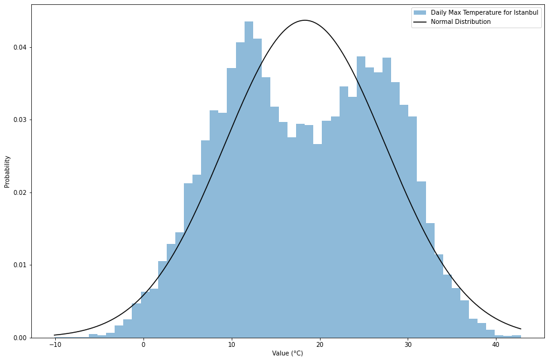

```python
plt.figure(figsize=(15, 10))
plt.hist(data, bins=bin_size, density=True, alpha=0.5, label='Daily Max Temperature for Istanbul')
plt.plot(x, normal_distribution_pdf, color='k', label='Normal Distribution')
plt.ylabel('Probability')
plt.xlabel('Value (°C)')
plt.legend()
plt.show()
```

## Gaussian Mixture Model

Let's fit a GMM to the data

```python
gmm = GaussianMixture(n_components=2, covariance_type='full', n_init=10).fit(data.reshape(-1, 1))

components_dict = {}
gmm_mixture = []
for i, (mean, cov, weight) in enumerate(zip(gmm.means_, gmm.covariances_, gmm.weights_)):
    temp = {'mean': mean[0],
            'stdev': math.sqrt(cov),
            'weight': weight}
    # gauss_key = 'Gauss_{number}'.format(number=i + 1)
    components_dict[i + 1] = temp
    gmm_mixture.append(np.random.normal(mean[0], math.sqrt(cov), size=math.ceil(len(data) * weight)))

# Creating a mixture of Gaussians
gmm_mixture = np.concatenate(gmm_mixture)

logprob = gmm.score_samples(x.reshape(-1, 1))
predict_prob = gmm.predict_proba(x.reshape(-1, 1))

#creating the pdf of the mixture of gaussians
gmm_pdf = np.exp(logprob)
gmm_pdf_individual = predict_prob * gmm_pdf[:, np.newaxis]
```

We can plot the PDF of GMM and PDFs of individual components together with the histogram. The normal distribution is also plotted to visually examine the goodness-of-fit.

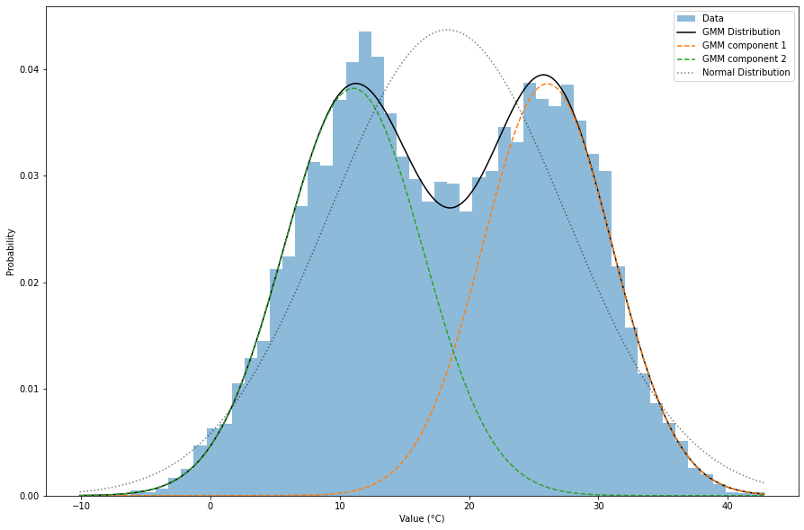

```python
plt.figure(figsize=(15, 10))
plt.hist(data, bins=bin_size, density=True, alpha=0.5, label='Data')
plt.plot(x, gmm_pdf, color='k', label='GMM Distribution')
plt.plot(x, gmm_pdf_individual, linestyle='--', label=['GMM component 1', 'GMM component 2'])
plt.plot(x, normal_distribution_pdf, color='k', linestyle=':', alpha=0.5, label='Normal Distribution')
plt.ylabel('Probability')
plt.xlabel('Value (°C)')
plt.legend()
plt.show()
```

## Generalized Extreme Value Distribution

Let's fit a GEV distribution to data and also test for different GEV shape parameters (0, -0.5 and 0.5).

```python
# shape value from data
shape, loc, scale = gev.fit(data, 1)

gev_distribution = gev.rvs(shape, loc, scale, size=n)
gev_distribution_pdf = gev.pdf(x, shape, loc, scale)

# shape = 0
gev_distribution_0 = gev.rvs(0, loc, scale, size=n)
gev_distribution_0_pdf = gev.pdf(x, 0, loc, scale)

# shape = -0.5
gev_distribution_n = gev.rvs(-0.5, loc, scale, size=n)
gev_distribution_n_pdf = gev.pdf(x, -0.5, loc, scale)

# shape = 0.5
gev_distribution_p = gev.rvs(0.5, loc, scale, size=n)
gev_distribution_p_pdf = gev.pdf(x, 0.5, loc, scale)
```

Now, we can plot the GEV distribution with parameters learned from the data and with predefined parameters (0, -0.5 and 0.5) together with the raw data

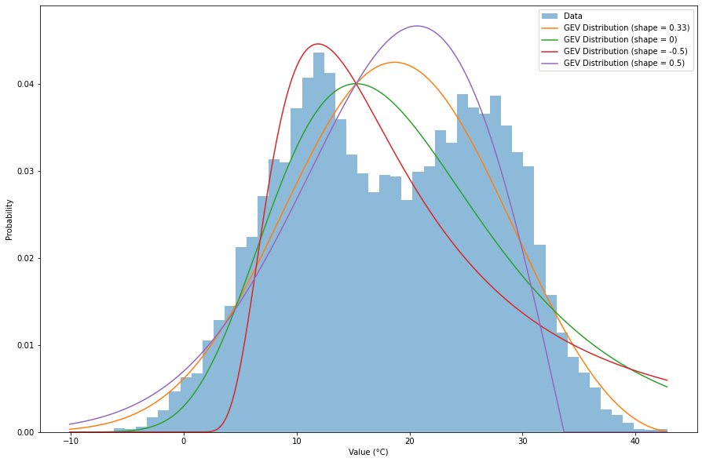

```python
plt.figure(figsize=(15, 10))
plt.hist(data, bins=bin_size, density=True, alpha=0.5, label='Data')
plt.plot(x, gev_distribution_pdf, label='GEV Distribution (shape = {})'.format(shape.round(2)))
plt.plot(x, gev_distribution_0_pdf, label='GEV Distribution (shape = 0)')
plt.plot(x, gev_distribution_n_pdf, label='GEV Distribution (shape = -0.5)')
plt.plot(x, gev_distribution_p_pdf, label='GEV Distribution (shape = 0.5)')
plt.ylabel('Probability')
plt.xlabel('Value (°C)')
plt.legend()
plt.show()
```

However, visual examination of the plots is not enough to determine the goodness-of-fit. We need to perform a statistical test. We will use Kolmogorov-Smirnov test to test the goodness-of-fit of the distributions. We will use the function from scipy.stats.ks_2samp to perform the test. The function returns the test statistic and the p-value. The null hypothesis is that the two samples are drawn from the same distribution. The smaller the p-value, the more likely it is that the two samples are drawn from different distributions.

```python
# Calculate the KS test for Normal, GMM, GEV, GEV with shape = 0, GEV with shape = 0.5, GEV with shape = -0.5
ks_list = [[stats.kstest(data, 'norm'), 'Normal Distribution'],
           [stats.kstest(data, gmm_mixture), 'GMM Distribution'],
           [stats.kstest(data, gev_distribution), 'GEV Distribution (shape = {})'.format(shape.round(2))],
           [stats.kstest(data, gev_distribution_0), 'GEV Distribution (shape = 0)'],
           [stats.kstest(data, gev_distribution_p), 'GEV Distribution (shape = 0.5)'],
           [stats.kstest(data, gev_distribution_n), 'GEV Distribution (shape = -0.5)'],
           ]
```

```python
ks_dataframe = pd.DataFrame([i for [i,j] in ks_list], index = [j for [i,j] in ks_list], columns = ['D', 'p-value'])
ks_dataframe = ks_dataframe.sort_values(by='D', ascending=False)
ks_dataframe
```

|  | D | p-value |
| --- | --- | --- |
| Normal Distribution | 0.962766 | 0.000000e+00 |
| GEV Distribution (shape = -0.5) | 0.197386 | 8.857936e-194 |
| GEV Distribution (shape = 0) | 0.095558 | 1.889360e-45 |
| GEV Distribution (shape = 0.5) | 0.091407 | 1.285107e-41 |
| GEV Distribution (shape = 0.33) | 0.056257 | 5.125057e-16 |
| GMM Distribution | 0.012167 | 3.687013e-01 |

## Plotting the data and all distributions

We can plot all distributions together with the raw data to visually examine the goodness-of-fit.

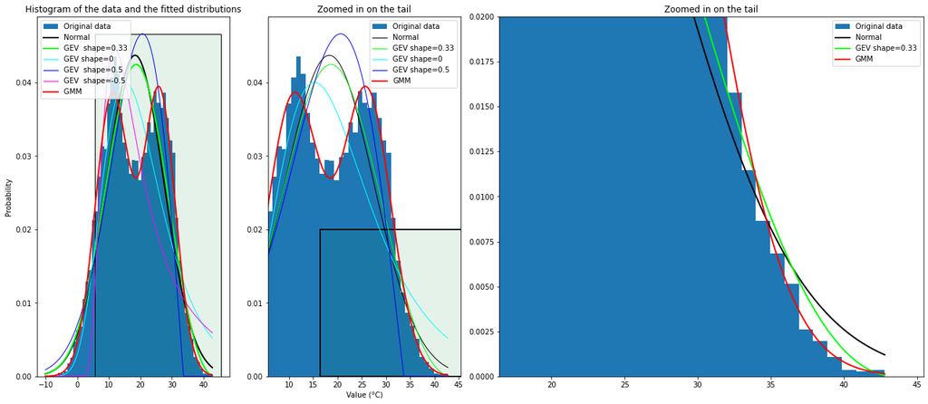

```python
# Plot the histogram.
fig = plt.figure(figsize=(20, 10))
fig.subplots_adjust(left=0.12, right=0.97,
                    bottom=0.21, top=0.9, wspace=0.2)

ax1 = fig.add_subplot(141)
ax1.hist(data, bins=bin_size, density=True, histtype='bar', label="Original data")
xmin, xmax = plt.xlim()

ax1.plot(x, normal_distribution_pdf, 'k', linewidth=2, label="Normal ")
ax1.plot(x, gev_distribution_pdf, 'lime', linewidth=2, label="GEV  shape={}".format(shape.round(2)))
ax1.plot(x, gev_distribution_0_pdf, color='cyan', linewidth=1, label="GEV shape=0")
ax1.plot(x, gev_distribution_p_pdf, color='blue', linewidth=1, label="GEV  shape=0.5")
ax1.plot(x, gev_distribution_n_pdf, color='magenta', linewidth=1, label="GEV  shape=-0.5")
ax1.plot(x, gmm_pdf, 'r', linewidth=2, label="GMM ")
# ax1.plot(x, gmm_pdf_individual, 'red', linewidth=1, linestyle='--', label="GMM individual")
# ax1.fill_between((components_dict[1]['mean']-components_dict[1]['stdev'], xmax), 0, max(gev_distribution_p_pdf), facecolor='green', alpha=0.2)
ax1.add_patch(Rectangle((components_dict[2]['mean']-components_dict[2]['stdev'], 0), xmax-(components_dict[2]['mean']-components_dict[2]['stdev']), max(gev_distribution_p_pdf),
                        facecolor=(0/255, 128/255, 50/255, 0.1),
                        edgecolor='black',
                        linewidth=1))
ax1.legend(loc='upper left')
ax1.title.set_text('Histogram of the data and the fitted distributions')

ax2 = fig.add_subplot(142)
ax2.hist(data, bins=bin_size, density=True, histtype='bar', label="Original data")
xmin, xmax = plt.xlim()

ax2.plot(x, normal_distribution_pdf, 'k', linewidth=1, label="Normal ")
ax2.plot(x, gev_distribution_pdf, 'lime', linewidth=1, label="GEV shape={}".format(shape.round(2)))
ax2.plot(x, gev_distribution_0_pdf, color='cyan', linewidth=1, label="GEV shape=0")
ax2.plot(x, gev_distribution_p_pdf, color='blue', linewidth=1, label="GEV shape=0.5")
ax2.plot(x, gmm_pdf, 'r', linewidth=2, label="GMM")
ax2.set_xlim(components_dict[2]['mean']-components_dict[2]['stdev'], xmax)

ax2.add_patch(Rectangle((components_dict[2]['mean'] + components_dict[2]['stdev'], 0), xmax, 0.02,
                        facecolor=(0/255, 128/255, 50/255, 0.1),
                        edgecolor='black',
                        linewidth=2))
ax2.legend()
ax2.title.set_text('Zoomed in on the tail')

ax3 = fig.add_subplot(1,4,(3,4))
ax3.hist(data, bins=bin_size, density=True, histtype='bar', label="Original data")
ax3.plot(x, normal_distribution_pdf, 'k', linewidth=2, label="Normal ")
ax3.plot(x, gev_distribution_pdf, 'lime', linewidth=2, label="GEV shape={}".format(shape.round(2)))
ax3.plot(x, gmm_pdf, 'r', linewidth=2, label="GMM")
ax3.set_xlim(components_dict[2]['mean'] + components_dict[2]['stdev'], xmax)
ax3.set_ylim(0, 0.02)
ax3.legend()
ax3.title.set_text('Zoomed in on the tail')
# set axis labels
ax1.set_ylabel('Probability')
ax2.set_xlabel('Value (°C)')


plt.show()
```